# Final Paper

BUS 696 Problem Set Template

Lauren Burke, Norman Gensinger, Ryan Richardson

```r
getwd()
```

```
## [1] "E:/Chapman/graduate-work/bs-696-bus-ml/final"
```

```r
# load all your libraries in this chunk
library('here')
library('forcats')
library('rsample')
library('plotROC')
library('glmnet')
library('glmnetUtils')
library('ggridges')
library('randomForest')
library('tidyverse')
library('magrittr')
library('splitstackshape')
library('lmerTest')
library('lme4')
library('corrplot')
library('RColorBrewer')
library('Hmisc')
library('PerformanceAnalytics')
library('ggstatsplot')
library("choroplethr")
library("choroplethrMaps")
library("usdata")
library("ggmap")
library("stats")
library("forcats")
library("MASS")
# note, do not run install.packages() inside a code chunk. install them in the console outside of a code chunk.
```

# Pre Processing Data

To begin, we read in our two data sets: the first that contains the apartments for rent, and the second that lists rent control by state as of 2019. We then replaced NULL values in the apartment data with NAs to allow for easier processing.

The first large cleanup item was separating the pet and amenity data from a single column in the original CSV format to a wide format of 0/1 values for each unique value.

We then added a new column for the total number of amenities. We excluded amenities_null from this sum.

We then converted the pet and amenity columns we created to factors, as well as converting a subset of other columns to factors as well. Next was converting bathrooms, bedrooms, longitude and latitude to numeric values. We did not include Bathrooms as factors due to the potential from 1/2 and 1/4 values as a possibility, nor did we include Bedrooms as factors to minimize the number of factors in our data set.

Next, we merged in the rent control data by state. 77 listings in our rental data set did not have state values. Since we are going to be looking at rent control by state, we have excluded those missing state values from our data set.

We then removed columns that are not strongly tied to our analysis. We are not going to pursue NLP analysis, so the title, body, price display, and long form address have been dropped. Currency and fee are dropped as all listings are identical with USD currency and no fee. Amenities_null is dropped, as in cases where amenities_null = 0, amenities_total is also 0, so the data is captured twice. ID is dropped because it has no relevance. Time is also dropped as we are looking at a snapshot of the data, not a time series or on the effects of posting time against price.

Next, we looked at the columns to judge relevance to our analyses. A few of the columns have less than five entries, so we dropped home, short_term, and price_types. Finally, we dropped the listings with NAs for bathrooms and bedrooms, as these do not meaningfully add to our data. They could be studios, or shared rooms in a house, we have no way of knowing.

```r
options(scipen = 50)
set.seed(1861)

apartment_raw <- read.csv(here("datasets", "apartments_for_rent_classified_10k.csv"),sep=";", header=TRUE)
state_rent_control <- read.csv(here("datasets", "state_rent_control.csv"))

apartment_raw = apartment_raw %>% replace(.=="NULL", NA)

apartment_raw = apartment_raw %>%
  mutate(amenities = strsplit(amenities, ",")) %>%
  unnest(amenities) %>%
  mutate(value = 1) %>%
  pivot_wider(names_from = amenities, names_prefix = 'amenities_', values_fill = 0) %>%
  mutate(pets_allowed = strsplit(pets_allowed, ",")) %>%
  unnest(pets_allowed) %>%
  mutate(value = 1) %>%
  pivot_wider(names_from = pets_allowed, names_prefix = 'allowedPet_', values_fill = 0)

apartment_raw = apartment_raw %>% mutate(amenities_total = rowSums(apartment_raw[,22:48]))
apartment_raw = apartment_raw %>% mutate_at(c(21:52), as.factor)
apartment_raw = apartment_raw %>% mutate_at(c("category", "state", "cityname", "source", "price_type", "has_photo", "fee", "currency"), as.factor)
apartment_raw = apartment_raw %>% mutate_at(c("bathrooms", "bedrooms", "latitude", "longitude"), as.numeric)

apartment_merge = merge(apartment_raw, state_rent_control, by.x="state", by.y="state")
apartment_merge = apartment_merge %>% mutate_at(c(54:55), as.factor)
apartment_clean = apartment_merge %>% select(-c("id", "title", "body", "time", "currency", "fee", "price_display", "address", "amenities_null"))

apartment_clean = apartment_clean %>%
  filter(category == "housing/rent/apartment") %>%
  filter(price_type == "Monthly") %>%
  filter(bathrooms != "NA") %>%
  filter(bedrooms != "NA")

apartment_clean = apartment_clean %>% select(-c("category", "price_type"))

summary(apartment_clean)
```

```
##      state        bathrooms        bedrooms         has_photo
##  TX     :1729   Min.   :1.000   Min.   :0.000   No       : 183
##  CA     : 950   1st Qu.:1.000   1st Qu.:1.000   Thumbnail:8787
##  WA     : 519   Median :1.000   Median :2.000   Yes      : 909
##  NC     : 437   Mean   :1.381   Mean   :1.747
##  MD     : 422   3rd Qu.:2.000   3rd Qu.:2.000
##  NJ     : 383   Max.   :8.500   Max.   :9.000
##  (Other):5439
##      price        square_feet             cityname       latitude
##  Min.   :  200   Min.   :  107.0   Austin     : 522   Min.   :21.32
##  1st Qu.:  949   1st Qu.:  650.0   Dallas     : 215   1st Qu.:33.67
##  Median : 1275   Median :  803.0   Houston    : 186   Median :38.76
##  Mean   : 1487   Mean   :  943.4   San Antonio: 182   Mean   :37.68
##  3rd Qu.: 1695   3rd Qu.: 1100.0   Los Angeles: 165   3rd Qu.:41.39
##  Max.   :52500   Max.   :11318.0   Chicago    : 147   Max.   :61.59
##                                    (Other)    :8462
##    longitude                source     amenities_Dishwasher
##  Min.   :-158.02   RentLingo   :6803   0:6632
##  1st Qu.:-101.30   RentDigs.com:2762   1:3247
##  Median : -93.65   ListedBuy   : 173
##  Mean   : -94.64   RealRentals :  69
##  3rd Qu.: -82.12   GoSection8  :  30
##  Max.   : -70.19   Listanza    :  20
##                    (Other)     :  22
##  amenities_Elevator amenities_Patio/Deck amenities_Pool
##  0:9243             0:7423               0:6663
##  1: 636             1:2456               1:3216
##
##
##
##
##
##  amenities_Storage amenities_Refrigerator amenities_AC
##  0:8353            0:6773                 0:9223
##  1:1526            1:3106                 1: 656
##
##
##
##
##
```

[output cut: 57 more lines]

```
##  0:8138          0:4228          0:4586          Min.   : 0.000
##  1:1741          1:5651          1:5293          1st Qu.: 0.000
##                                                  Median : 2.000
##                                                  Mean   : 3.131
##                                                  3rd Qu.: 5.000
##                                                  Max.   :18.000
##
##  prohibit_rent_control implements_rent_control
##  N:2708                N:8056
##  Y:7171                Y:1823
##
##
##
##
##
```

# Visualisations

## Cross Correlation

OOur first graph is to visualize the cross correlation between our non-factor variables to limit or identify whether there is a significant relationship between our quantitative predictors. In this we see that that Bathrooms, Bedrooms, Price, Square Footage, and Total Amenities all share a very similar distribution, slightly skewed with a long tail, which indicates that all of our predictors are likely correlated and should be included in our analysis.

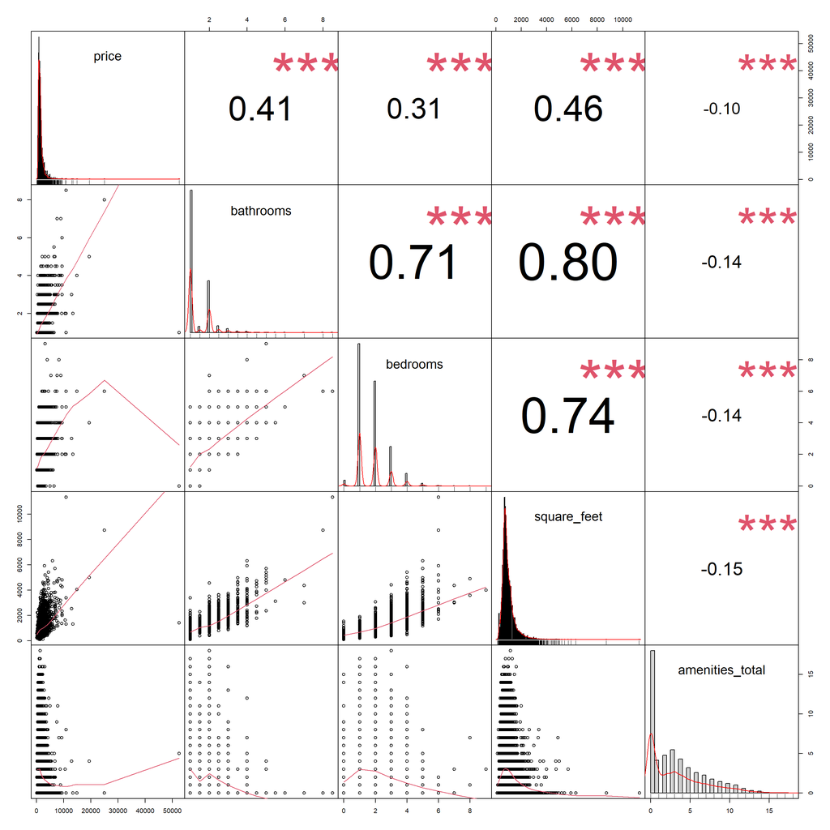

```r
chart.Correlation(apartment_clean[, c("price","bathrooms","bedrooms","square_feet","amenities_total")], histogram=TRUE, pch=19)
```

## Cross Correlation Non-Zero Amenities

We also extend this graph to look at the relationship as we remove listings that do not include amenities. We see some of these relationships reduce their total effect size while remaining statistically significant.

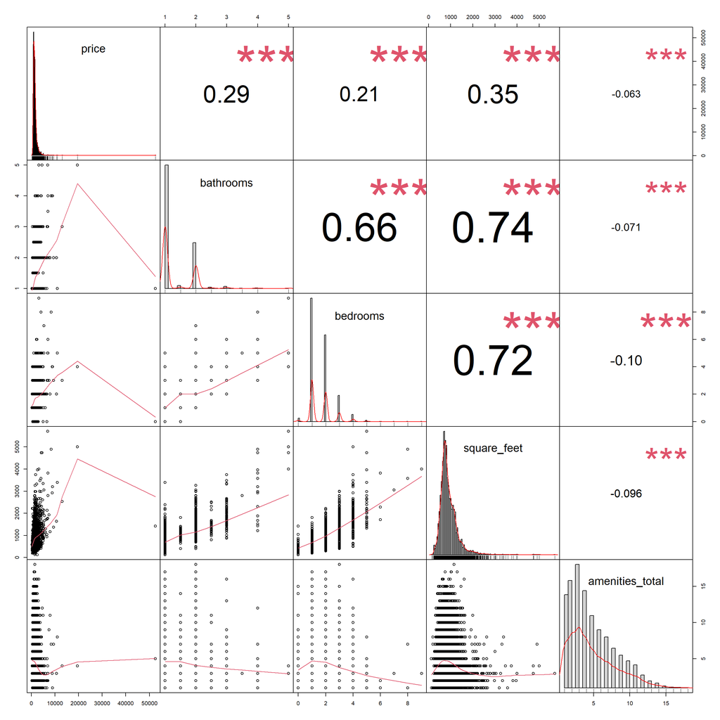

```r
apartment_nonZero = apartment_clean %>% filter(amenities_total != 0)

chart.Correlation(apartment_nonZero[, c("price","bathrooms","bedrooms","square_feet","amenities_total")], histogram=TRUE, pch=19)
```

## Amenit Distribution by State

Plotting the average rental price over the total number of amenities shows a slightly negative correlation between the two variables, which is also reflected in the correlation coefficient of ~ -0.1 reducing to -0.06 when we remove listings that have 0 amenities listed.

For most states with sufficient data points, this observation seems contrary to the expectation that more amenities would lead to a higher listing price. We will need to further analyze why an increase in total amenities generally results in a decrease in rental price within the underlying data set.

One potential explanation for the decrease is that some amenities (such as AC, Internet Access, Dishwasher, etc) are expected inclusions for many seeking to rent and do not need to be individually listed, or that the author of the post didn’t list them in the proper fashion. It may cause a negative reaction in an individual when they see basic amenities listed as a selling point, though it’s not entirely clear as to why this relationship is negative without further analysis. This is partially refuted by the effect of removing listings that have 0 amenities listed.

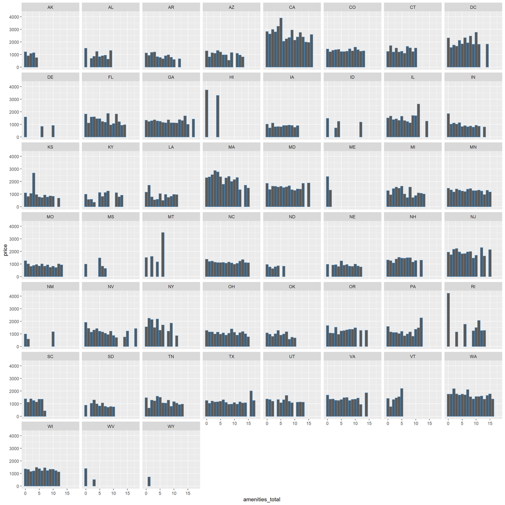

```r
ggplot(data = apartment_clean %>% arrange(desc(state)), aes(x = amenities_total, y = price)) +
  geom_bar(stat = "summary", fun = "mean", color = "steelblue") +
  facet_wrap(~ state)
```

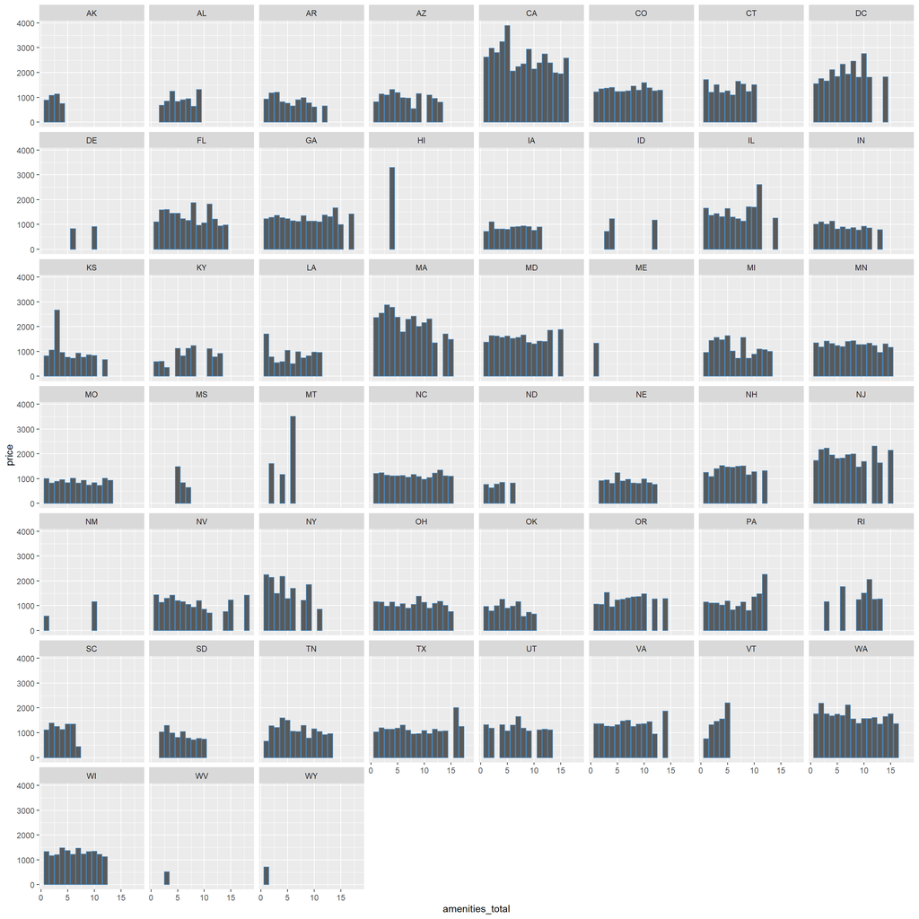

```r
ggplot(data = apartment_clean %>% filter(amenities_total != 0) %>% arrange(desc(state)), aes(x = amenities_total, y = price)) +
  geom_bar(stat = "summary", fun = "mean", color = "steelblue") +
  facet_wrap(~ state)
```

## Prices by State

Looking across the entire continental US we can get an idea of where apartment prices are highest and get a sense of how location affects prices. We can then use this data to look at the potential effects of rent control on the total prices and their distributions. Based on the rent control by state, we can already see that California, New Jersey, and New York have higher prices despite having rent control implementations across various cities and locations. This could suggest that rent control itself is an effect of high prices, rather than a cause of said high prices. Visually, there appears to be correlation between rent control implementation and price at the very least which we will try to explore in our analysis.

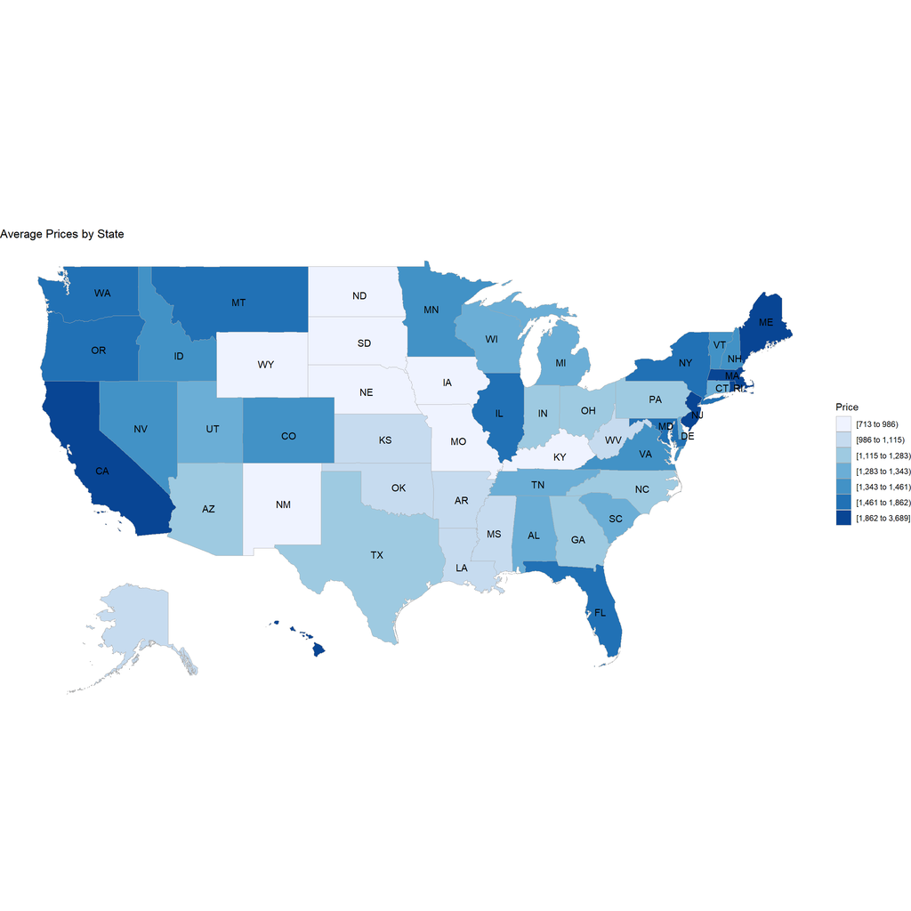

```r
register_google(key = "AIzaSyC8eFoti2mPoYz918n3sJcWoWkIn6K6nnw")
choro = apartment_clean %>% group_by(state) %>% summarise_at(vars(price), list(value=mean))
names(choro)[1] = 'region'
choro = choro %>% mutate(region = tolower(abbr2state(region)))

data(continental_us_states)

state_choropleth(df=choro, title="Average Prices by State", legend ="Price")
```

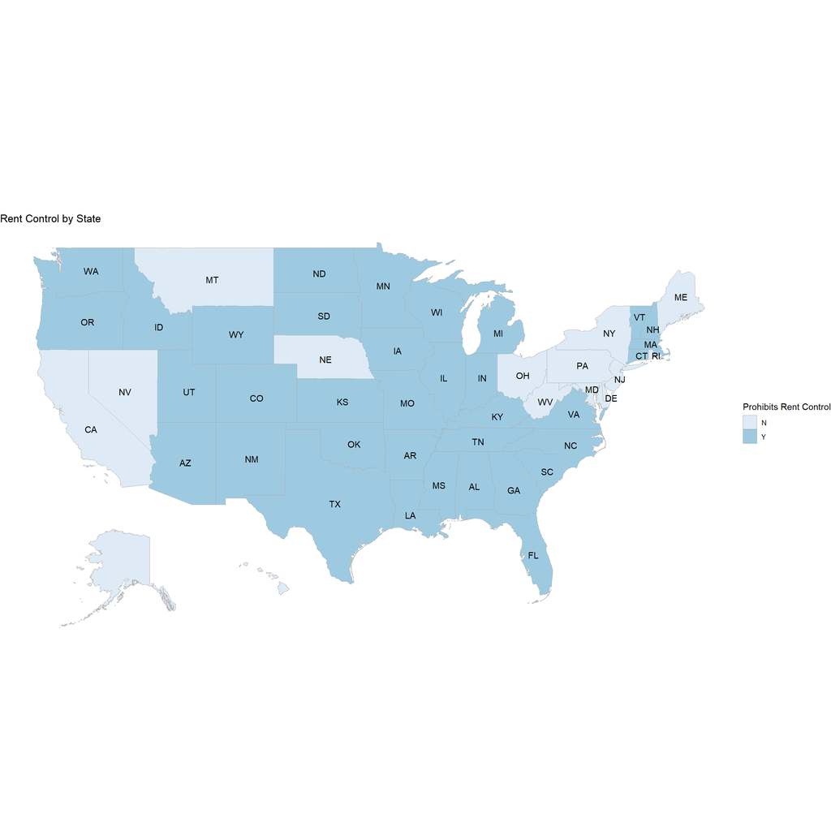

```r
register_google(key = "AIzaSyC8eFoti2mPoYz918n3sJcWoWkIn6K6nnw")
choro_rent = state_rent_control %>% dplyr::select(c(state, prohibit_rent_control))
names(choro_rent)[1] = 'region'
names(choro_rent)[2] = 'value'
choro_rent = choro_rent %>% mutate(region = tolower(abbr2state(region)))

data(continental_us_states)

state_choropleth(df=choro_rent, title="Rent Control by State", legend ="Prohibits Rent Control")
```

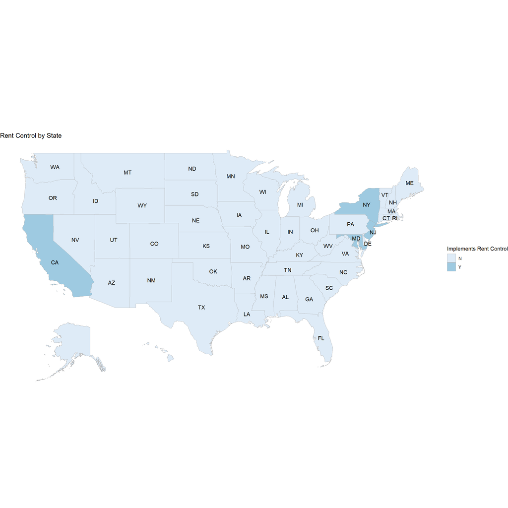

```r
register_google(key = "AIzaSyC8eFoti2mPoYz918n3sJcWoWkIn6K6nnw")
choro_rent = state_rent_control %>% dplyr::select(c(state, implements_rent_control))
names(choro_rent)[1] = 'region'
names(choro_rent)[2] = 'value'
choro_rent = choro_rent %>% mutate(region = tolower(abbr2state(region)))

data(continental_us_states)

state_choropleth(df=choro_rent, title="Rent Control by State", legend ="Implements Rent Control")
```

Before continuing we want to identify outliers that may exist in the model to reduce their impact on the potential model.

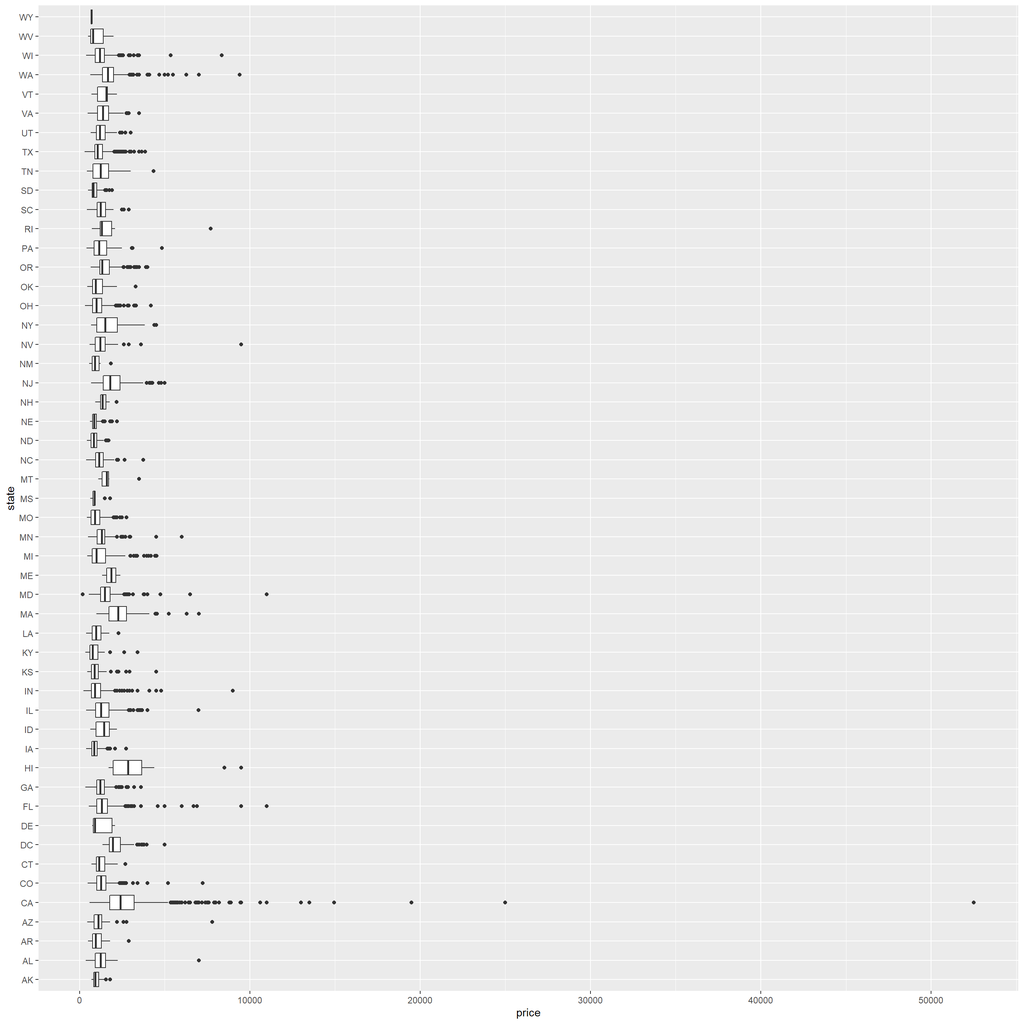

```r
boxPlotByState <- ggplot(apartment_clean, aes(price,state)) + geom_boxplot()
boxPlotByState
```

```r
remove_outliers <- function(x, na.rm = TRUE, ...) {
  qnt <- quantile(x, probs=c(.25, .75), na.rm = na.rm, ...)
  H <- 1.5 * IQR(x, na.rm = na.rm)
  y <- x
  y[x < (qnt[1] - H)] <- NA
  y[x > (qnt[2] + H)] <- NA
  y
}

apartment_clean_no_outliers <- apartment_clean %>%
    group_by(state) %>%
    mutate(price = remove_outliers(price))
```

We can clearly see multiple outliers that exist in california, Florida, Hawaii, Maryland, Nevada, Rhode Island, Washington, and Wisconsin that we would like to try and remove.

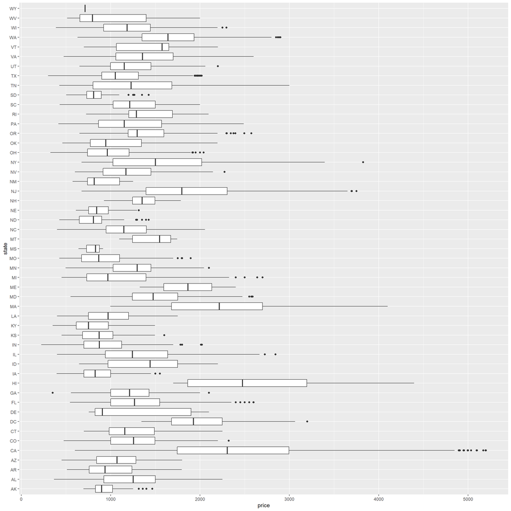

```r
apartment_clean_no_outliers <- na.omit(apartment_clean_no_outliers)
boxBlotNoOutliers <- ggplot(apartment_clean_no_outliers, aes(price,state)) + geom_boxplot()
boxBlotNoOutliers
```

After removing the outliers we see a much more varied distribution in the prices. While there are still prices just outside of the boxplot ranges, they are close enough and clustered enough that they shouldn’t significantly impact our analysis. We are left with 9,448 observations after cleaning and outlier removal.At this stage, we are also going to remove Latitude and Longitude from our data as they were primarily left in for mapping purposes. We are also going to remove the citynames from our dataset as the majority of the cities have very only a handful of observations in them, and including them could greatly increase the bias of our model without much benefit in the prediction strength.

Our first run resulted problems with our rent control, state, and total amenities variables being perfectly colinear with other variables. It is easy to see that the combined rent control data is colinear with the state effects. So we selectively remove some columns to discover a model without these colinearities.

```r
acno = apartment_clean_no_outliers %>% ungroup() %>% dplyr::select(-c(latitude, longitude, cityname, state, amenities_total))
acno %>%group_by(source) %>% summarise(no_rows = length(source))
```

| source | no_rows |
| --- | --- |
| GoSection8 | 30 |
| Home Rentals | 1 |
| Listanza | 20 |
| ListedBuy | 168 |
| Real Estate Agent | 1 |
| RealRentals | 66 |
| rentbits | 2 |
| RENTCafi | 1 |
| RentDigs.com | 2703 |
| RentLingo | 6441 |

[output cut: 2 more lines]

```r
acno$source = fct_lump(acno$source, n=6)
acno %>%group_by(source) %>% summarise(no_rows = length(source))
```

| source | no_rows |
| --- | --- |
| GoSection8 | 30 |
| Listanza | 20 |
| ListedBuy | 168 |
| RealRentals | 66 |
| RentDigs.com | 2703 |
| RentLingo | 6441 |
| Other | 20 |

```r
acnoSplit <- initial_split(acno, 0.7)
acnoTrain <- training(acnoSplit)
acnoTest <- testing(acnoSplit)
```

```r
acNoStepModel = lm(price ~., data=acnoTrain)
summary(acNoStepModel)
```

```
##
## Call:
## lm(formula = price ~ ., data = acnoTrain)
##
## Residuals:
##      Min       1Q   Median       3Q      Max
## -1633.59  -292.91   -77.61   208.60  3073.60
##
## Coefficients:
##                                   Estimate Std. Error t value
## (Intercept)                      686.67611  132.98180   5.164
## bathrooms                        152.81849   18.10545   8.440
## bedrooms                          11.45512   10.80448   1.060
## has_photoThumbnail                23.03789   46.39416   0.497
## has_photoYes                     -31.69112   48.23719  -0.657
## square_feet                        0.39781    0.02511  15.840
## sourceListanza                   443.63695  181.19735   2.448
## sourceListedBuy                 -136.64546  113.02324  -1.209
## sourceRealRentals                385.05912  128.76603   2.990
## sourceRentDigs.com                41.00210  106.36416   0.385
## sourceRentLingo                  121.04392  106.52722   1.136
## sourceOther                      -21.05360  159.02158  -0.132
## amenities_Dishwasher1             46.73344   19.81987   2.358
## amenities_Elevator1              213.69808   26.14163   8.175
## `amenities_Patio/Deck`1           -2.48404   17.52941  -0.142
## amenities_Pool1                  -49.21239   15.92982  -3.089
## amenities_Storage1                49.67840   18.41801   2.697
## amenities_Refrigerator1          -16.03453   21.16918  -0.757
## amenities_AC1                   -114.97303   28.75610  -3.998
## amenities_Basketball1            -13.90565   35.52305  -0.391
## `amenities_Cable or Satellite`1 -103.48778   23.75668  -4.356
## amenities_Gym1                    93.93403   22.74248   4.130
## `amenities_Internet Access`1      52.16738   23.13491   2.255
## amenities_Clubhouse1              37.19895   21.19503   1.755
## amenities_Parking1                13.97114   15.07380   0.927
## `amenities_Garbage Disposal`1    -96.28944   23.45859  -4.105
## amenities_Fireplace1              -2.29165   21.22147  -0.108
## `amenities_Washer Dryer`1        -26.95137   23.97474  -1.124
## amenities_Playground1           -208.52133   24.52789  -8.501
## amenities_Gated1                  -0.01066   29.41622   0.000
```

[output cut: 52 more lines]

```
## amenities_Doorman1                           0.21762
## amenities_Luxury1                            0.51535
## amenities_Golf1                              0.92096
## allowedPet_None1                             0.00131 **
## allowedPet_null1                             0.04549 *
## allowedPet_Cats1                             0.00115 **
## allowedPet_Dogs1                             0.88078
## prohibit_rent_controlY                       0.34478
## implements_rent_controlY        < 0.0000000000000002 ***
## ---
## Signif. codes:  0 '***' 0.001 '**' 0.01 '*' 0.05 '.' 0.1 ' ' 1
##
## Residual standard error: 486.1 on 6568 degrees of freedom
## Multiple R-squared:  0.4544, Adjusted R-squared:  0.4508
## F-statistic: 124.3 on 44 and 6568 DF,  p-value: < 0.00000000000000022
```

```r
lm_preds_test = predict(acNoStepModel, newdata=acnoTest)
lm_mse = sqrt(mean((acnoTest$price - lm_preds_test[1])^2))
print(lm_mse)
```

```
## [1] 729.4966
```

```r
model_mse = data.frame("LinearRegression" = c(lm_mse), "ElasticNet" = c(0), "RandomForest" = c(0))
model_mse
```

| LinearRegression | ElasticNet | RandomForest |
| --- | --- | --- |
| 729.4966 | 0 | 0 |

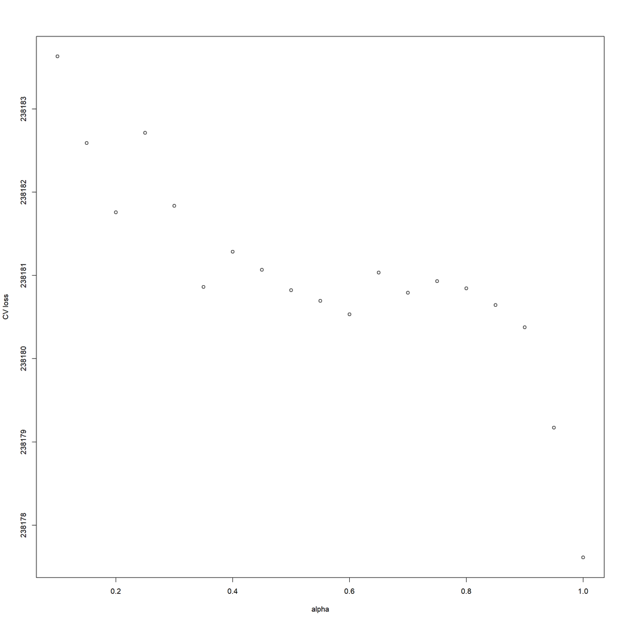

```r
en_mod <- cva.glmnet(price ~.,
                     data=acnoTrain,
                     alpha=seq(0.1,1, by=0.05), nlambda=100)

minlossplot(en_mod, cv.type="min")
```

```r
en_mod <- cva.glmnet(price ~.,
                     data=acnoTrain,
                     alpha=0.95, nlambda=100)
preds_test <- data.frame(predict(en_mod, acnoTest, alpha = 0.95, na.action = na.pass))
en_mse = sqrt(mean((acnoTest$price - preds_test[,1])^2))

model_mse = data.frame("LinearRegression" = c(lm_mse), "ElasticNet" = c(en_mse), "RandomForest" = c(0))
model_mse
```

| LinearRegression | ElasticNet | RandomForest |
| --- | --- | --- |
| 729.4966 | 495.8442 | 0 |

Next we will assess a random forest. We have 51 total variables if we include all included factor levels and their bases, which suggests we should have our mtry around 7. We also need to change our factor names to make them compatible with the random forest package in this instance.

```r
names(acnoTest) <- make.names(names(acnoTest))
names(acnoTrain) <- make.names(names(acnoTrain))
rf_mod = randomForest(price ~ ., data=acnoTrain, mtry=7,ntree=200, importance=TRUE)
rf_mod$importance
```

```
##                                    %IncMSE IncNodePurity
## bathrooms                     64007.758570   175754994.3
## bedrooms                      43706.329302   112074500.8
## has_photo                      3348.428503    29410910.3
## square_feet                  100766.691287   405212942.1
## source                        42816.163543    77516931.8
## amenities_Dishwasher          22179.028982    34076176.7
## amenities_Elevator            11926.344869    33425387.2
## amenities_Patio.Deck          13190.630013    27822446.4
## amenities_Pool                20809.687420    35515790.1
## amenities_Storage              7089.718280    25032429.9
## amenities_Refrigerator        36566.410910    42398366.1
## amenities_AC                   3684.137648    15717333.7
## amenities_Basketball           1467.799333     9186479.0
## amenities_Cable.or.Satellite  12874.910293    24541686.6
## amenities_Gym                 12045.689107    21081072.0
## amenities_Internet.Access      7177.788107    17813727.1
## amenities_Clubhouse            6355.396025    17594788.6
## amenities_Parking             15198.124630    34373243.1
## amenities_Garbage.Disposal     7298.310897    16124622.8
## amenities_Fireplace            5768.068638    19460282.3
## amenities_Washer.Dryer         4786.403945    17928851.3
## amenities_Playground          13040.593641    30665511.6
## amenities_Gated                1443.912729    11236543.1
## amenities_TV                    605.695061     6649606.5
## amenities_Hot.Tub              2508.349478    14007709.8
## amenities_Tennis               2204.802717    13146286.1
## amenities_Wood.Floors          1993.739191    16814921.1
## amenities_View                 2243.647825    12850610.3
## amenities_Alarm                  69.111631     1131486.7
## amenities_Doorman                41.679089     2029970.2
## amenities_Luxury                  2.001303      216789.0
## amenities_Golf                   14.483705      754385.1
## allowedPet_None               17924.194481    19620538.5
## allowedPet_null               13735.538961    20096973.3
## allowedPet_Cats               30059.656252    26973006.8
## allowedPet_Dogs               29783.767253    26214705.4
## prohibit_rent_control         71662.981637   219700760.2
## implements_rent_control      236006.979144   552938696.3
```

We see the MSE drops substantially as our number of tress increases. Based on this information, we should keep our number of trees around 125, any more than that as we see no significant increase or decrease in MSE beyond that range.

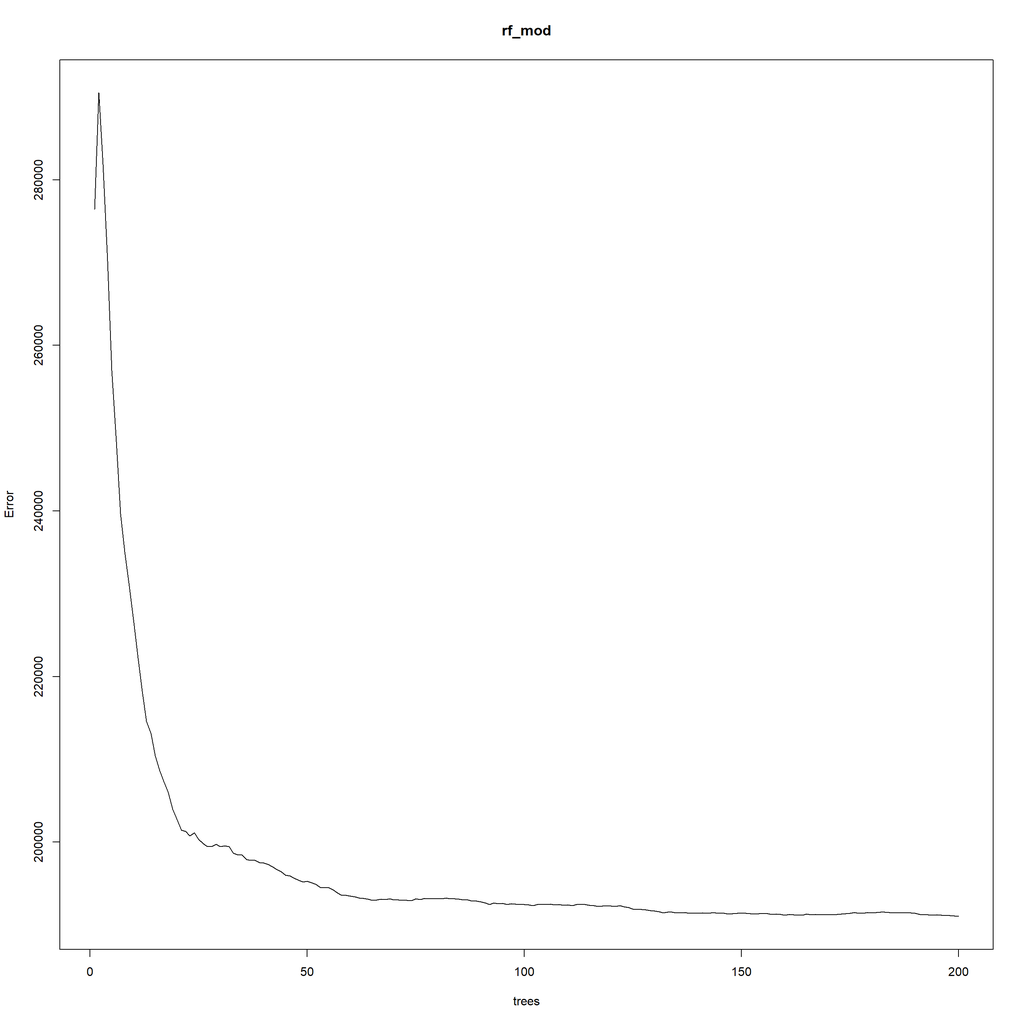

```r
plot(rf_mod)
```

Our in bag and out of bag prediction RMSE suggests that aour model is overfit to a greater degree than we might like. This may be due to how specific our indicators are, biasing our predictions a bit highly. We may be able to adjust this by grouping more of our factors together than we did originally.

```r
in_bag = predict(rf_mod, acnoTrain, type="response")
out_of_bag = predict(rf_mod, type="response")
test_predictions = predict(rf_mod, acnoTest, type="response")



inbag = sqrt(mean((acnoTrain$price - in_bag)^2))
print("OOB")
```

```
## [1] "OOB"
```

```r
outbag = sqrt(mean((acnoTrain$price - out_of_bag)^2))

rf_mse = sqrt(mean((acnoTest$price - test_predictions)^2))


rf_bags = data.frame("InBag" = c(inbag), "OutOfBag" = c(outbag), "Test" = c(rf_mse))
rf_bags
```

| InBag | OutOfBag | Test |
| --- | --- | --- |
| 318.7957 | 437.0823 | 447.7027 |

```r
model_mse = data.frame("LinearRegression" = c(lm_mse), "ElasticNet" = c(en_mse), "RandomForest" = c(rf_mse))
model_mse
```

| LinearRegression | ElasticNet | RandomForest |
| --- | --- | --- |
| 729.4966 | 495.8442 | 447.7027 |